# Homework #2

Andrew Sundberg; andrewsundberg

## R commands

1. Today’s temperature has a high of 15 and a low of -10 degree fahrenheit. Find the corresponding degress in celsius and storage it in a (single) vector named `cel`. Print the variable.

```r
fahr = c(15, -10)
cel = (((fahr - 32) * 5) / 9)
cel
```

```
## [1]  -9.444444 -23.333333
```

```r
vec200 = rep(c(0,1), 100)
vec200
```

```
##   [1] 0 1 0 1 0 1 0 1 0 1 0 1 0 1 0 1 0 1 0 1 0 1 0 1 0 1 0 1 0 1 0 1 0 1 0
##  [36] 1 0 1 0 1 0 1 0 1 0 1 0 1 0 1 0 1 0 1 0 1 0 1 0 1 0 1 0 1 0 1 0 1 0 1
##  [71] 0 1 0 1 0 1 0 1 0 1 0 1 0 1 0 1 0 1 0 1 0 1 0 1 0 1 0 1 0 1 0 1 0 1 0
## [106] 1 0 1 0 1 0 1 0 1 0 1 0 1 0 1 0 1 0 1 0 1 0 1 0 1 0 1 0 1 0 1 0 1 0 1
## [141] 0 1 0 1 0 1 0 1 0 1 0 1 0 1 0 1 0 1 0 1 0 1 0 1 0 1 0 1 0 1 0 1 0 1 0
## [176] 1 0 1 0 1 0 1 0 1 0 1 0 1 0 1 0 1 0 1 0 1 0 1 0 1
```

3. How many perfect squares are there between 1 and 1001? Storage the answer in a variable named `numPerfect` and print. You may want to look at `?round`.

```r
numPerfect = floor(sqrt(1001)) - ceiling(sqrt(1)) + 1
numPerfect
```

```
## [1] 31
```

1. What are the 3 most fuel-efficient models in terms of highway mileage? Storage the data frame (with 3 rows) containing all information of these three cars in a variable named `top3` and print.

```r
library(ggplot2)
newdata = mpg[order(mpg$hwy),]
top3 = tail(newdata,3)
top3
```

```
## # A tibble: 3 x 11
##   manufacturer model displ  year   cyl trans drv     cty   hwy fl    class
##   <chr>        <chr> <dbl> <int> <int> <chr> <chr> <int> <int> <chr> <chr>
## 1 volkswagen   new ~  1.90  1999     4 auto~ f        29    41 d     subc~
## 2 volkswagen   jetta  1.90  1999     4 manu~ f        33    44 d     comp~
## 3 volkswagen   new ~  1.90  1999     4 manu~ f        35    44 d     subc~
```

2. How many different compact models are included in this dataset? Storage the answer in a variable named `numCompact` and print.

```r
compact_mpg = mpg[mpg$class == 'compact',]
numCompact = length(unique(compact_mpg$model))
numCompact
```

```
## [1] 8
```

3. Create a scatterplot of `hwy` and `cty` and describe the relationship. Why are there so few points visible?

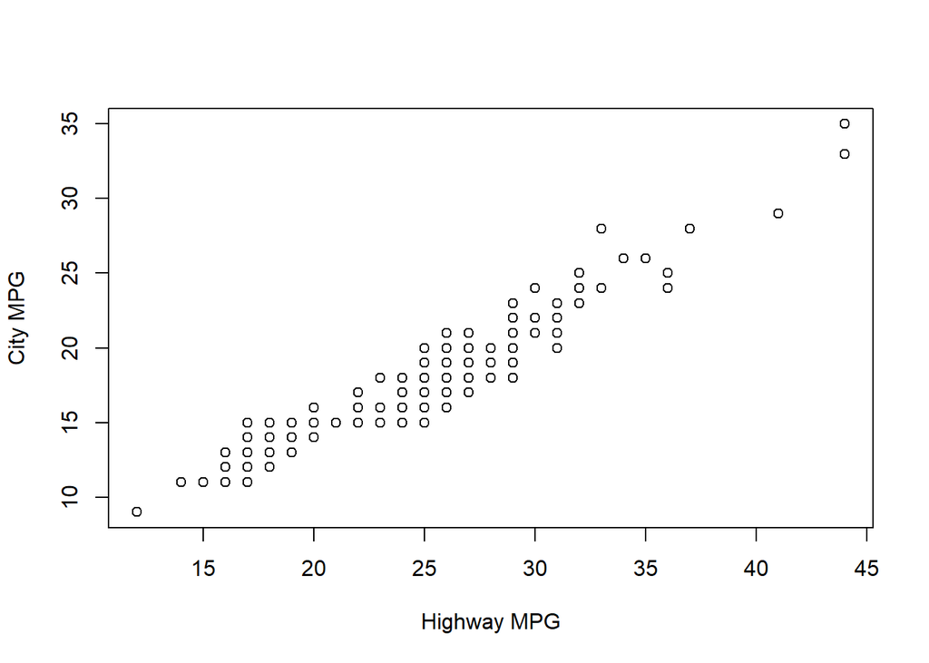

```r
plot(mpg$hwy, mpg$cty, xlab = 'Highway MPG', ylab = 'City MPG')
```

There are missing points because there are multiple cars in the same data point in some cases.

4. Are cars in 2008 more fuel efficient than cars in 1999? Use graphs *and* summary statistics to answer this question.

```r
mpg1999 = mpg[mpg$year == 1999,]
mpg2008 = mpg[mpg$year == 2008,]

summary(mpg1999)
```

```
##  manufacturer          model               displ            year
##  Length:117         Length:117         Min.   :1.600   Min.   :1999
##  Class :character   Class :character   1st Qu.:2.200   1st Qu.:1999
##  Mode  :character   Mode  :character   Median :3.000   Median :1999
##                                        Mean   :3.281   Mean   :1999
##                                        3rd Qu.:4.000   3rd Qu.:1999
##                                        Max.   :6.500   Max.   :1999
##       cyl           trans               drv                 cty
##  Min.   :4.000   Length:117         Length:117         Min.   :11.00
##  1st Qu.:4.000   Class :character   Class :character   1st Qu.:14.00
##  Median :6.000   Mode  :character   Mode  :character   Median :17.00
##  Mean   :5.692                                         Mean   :17.02
##  3rd Qu.:6.000                                         3rd Qu.:19.00
##  Max.   :8.000                                         Max.   :35.00
##       hwy             fl               class
##  Min.   :15.00   Length:117         Length:117
##  1st Qu.:17.00   Class :character   Class :character
##  Median :25.00   Mode  :character   Mode  :character
##  Mean   :23.43
##  3rd Qu.:26.00
##  Max.   :44.00
```

```r
summary(mpg2008)
```

```
##  manufacturer          model               displ            year
##  Length:117         Length:117         Min.   :1.800   Min.   :2008
##  Class :character   Class :character   1st Qu.:2.500   1st Qu.:2008
##  Mode  :character   Mode  :character   Median :3.600   Median :2008
##                                        Mean   :3.662   Mean   :2008
##                                        3rd Qu.:4.700   3rd Qu.:2008
##                                        Max.   :7.000   Max.   :2008
##       cyl           trans               drv                 cty
##  Min.   :4.000   Length:117         Length:117         Min.   : 9.0
##  1st Qu.:4.000   Class :character   Class :character   1st Qu.:13.0
##  Median :6.000   Mode  :character   Mode  :character   Median :17.0
##  Mean   :6.085                                         Mean   :16.7
##  3rd Qu.:8.000                                         3rd Qu.:20.0
##  Max.   :8.000                                         Max.   :28.0
##       hwy             fl               class
##  Min.   :12.00   Length:117         Length:117
##  1st Qu.:18.00   Class :character   Class :character
##  Median :24.00   Mode  :character   Mode  :character
##  Mean   :23.45
##  3rd Qu.:28.00
##  Max.   :37.00
```

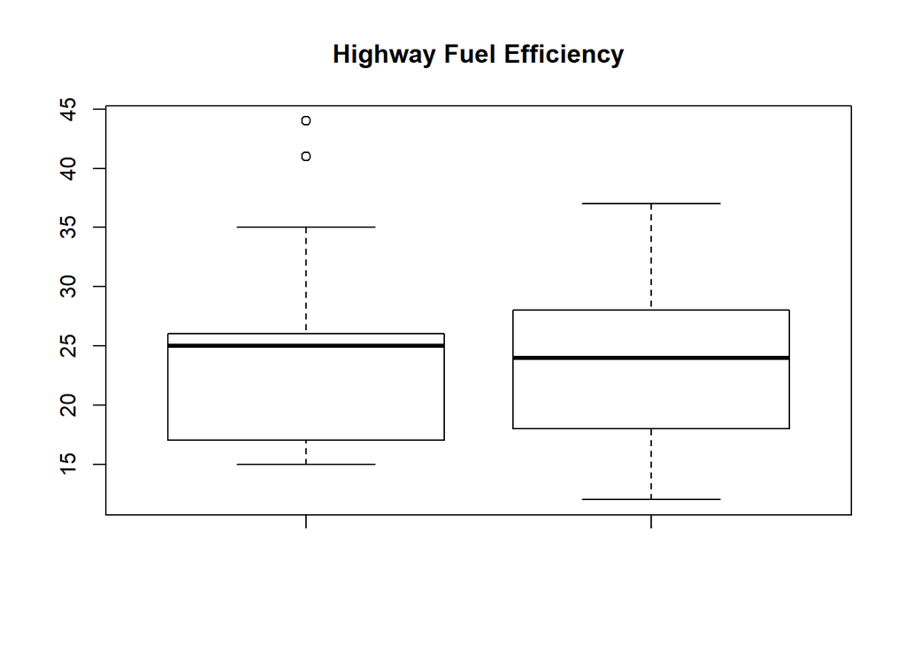

```r
boxplot(mpg1999$hwy, mpg2008$hwy, main = 'Highway Fuel Efficiency')
```

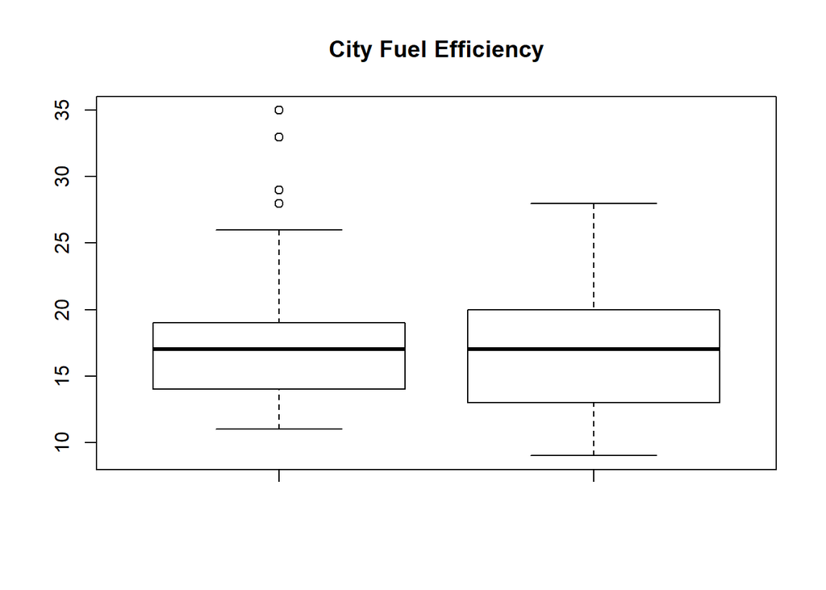

```r
boxplot(mpg1999$cty, mpg2008$cty, main = 'City Fuel Efficiency')
```